# clinical_analyses

```r
# PC4
pca_loadings %>%
  select(feature, PC4) %>%
  mutate(PC4 = round(PC4, 3)) %>%
  arrange(desc(abs(PC4))) %>%
  print(n = Inf)
```

```
## # A tibble: 20 × 2
##    feature                                        PC4
##    <chr>                                        <dbl>
##  1 DSS_tbl_IR                                   0.459
##  2 past_overgeneralization_errors_per_past_opp -0.385
##  3 DSS_tbl_WHQ                                  0.324
##  4 pronoun_errors_per_word                     -0.291
##  5 repetition_per_utt                          -0.288
##  6 DSS_tbl_SV                                  -0.254
##  7 Word_Errors_per_utt                         -0.252
##  8 DSS_tbl_NG                                   0.243
##  9 MLU_Morphemes                               -0.239
## 10 DSS_tbl_CNJ                                 -0.236
## 11 VOCD_D_optimum_average                       0.191
## 12 DSS_tbl_score                               -0.111
## 13 DSS_tbl_PP                                  -0.077
## 14 Syntax_Coordination_Utt_Prop                -0.074
## 15 DSS_tbl_IP                                   0.072
## 16 Syntax_Subordination_Utt_Prop               -0.04
## 17 DSS_tbl_MV                                  -0.022
## 18 Syntax_ComplexNP_Utt_Prop                   -0.009
## 19 Syntax_Max_DepLen                            0.006
## 20 Syntax_AuxCop_Utt_Prop                      -0.001
```

- PC1: syntactic complexity; higher = more syntactically complex speech (> coordination & subordination; longer & deeper structures; > complex NPs; > aux/copulas structures).
- PC2: grammatical maturity; higher = longer, grammatically richer sentences and phrase structures, less word-level errors.
- PC3: error proneness and lexical instability; lower lexical richness.
- PC4: Residual morphosyntactic control; a weaker residual component, roughly contrasting interrogative/irregular-form control with errorful production

```r
library(dplyr)

pca_scores_named <- pca_scores %>%
  rename(
    Syntactic_Complexity = PC1,
    Grammatical_Maturity = PC2,
    Error_Disfluency = PC3,
    Residual_Morphosyntactic_Control = PC4
  )
```

```r
library(dplyr)
library(GGally)
```

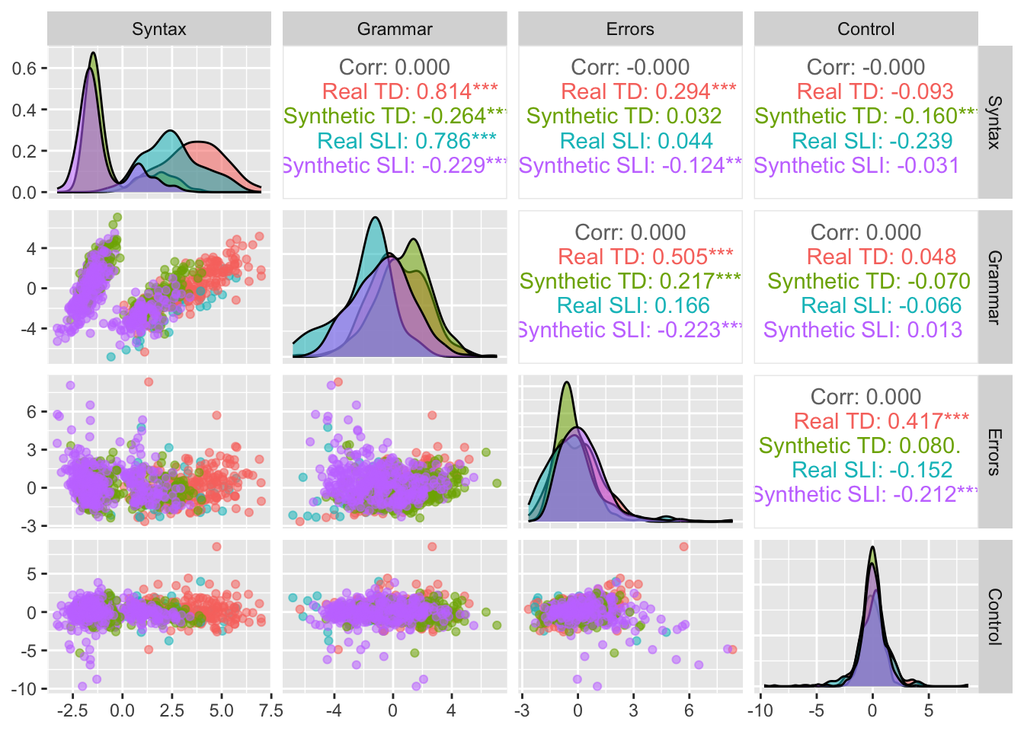

```r
pca_scores_plotly <- as.data.frame(pca_fit$x) %>%
  mutate(
    population = pca_complete$population,
    PC3 = -PC3
  ) %>%
  rename(
    Syntax  = PC1,
    Grammar = PC2,
    Errors  = PC3,
    Control = PC4
  )

GGally::ggpairs(
  pca_scores_plotly,
  columns = c(
    "Syntax",
    "Grammar",
    "Errors",
    "Control"
  ),
  aes(color = population, alpha = 0.7)
)
```

The first two components already separate the populations in a meaningful way, but not perfectly. Synthetic data are not identical to real data, and synthetic SLI does not sit neatly on top of real SLI.

- PC1-PC2 correlation: real strong positive correlation; synthetic weakly negative correlation.= In the real data, more syntactic complexity tends to go together with more grammatical maturity. In the synthetic data, that relationship is not preserved in the same way.

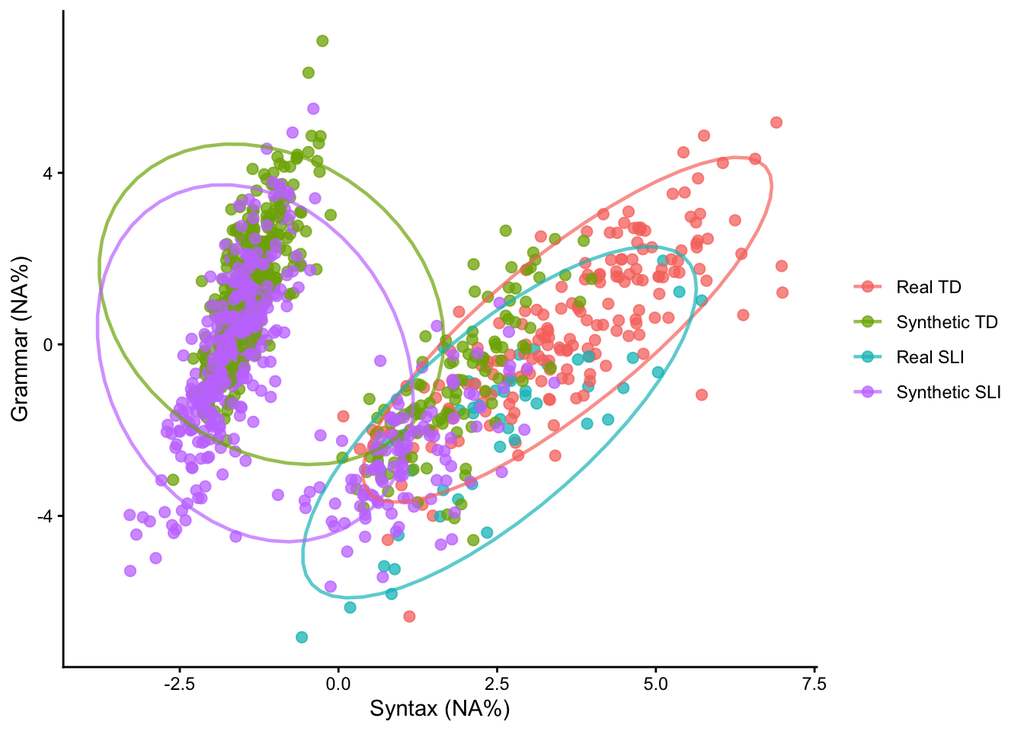

```r
library(ggplot2)

plot_pc <- function(df, xpc, ypc, var_explained) {
  ggplot(df, aes_string(x = xpc, y = ypc, color = "population")) +
    geom_point(size = 2.2, alpha = 0.75) +
    stat_ellipse(linewidth = 0.8, alpha = 0.7) +
    labs(
      x = paste0(xpc, " (", round(100 * var_explained[as.numeric(sub("PC", "", xpc))], 1), "%)"),
      y = paste0(ypc, " (", round(100 * var_explained[as.numeric(sub("PC", "", ypc))], 1), "%)"),
      color = NULL
    ) +
    theme_classic()
}

plot_pc(pca_scores_plotly, "Syntax", "Grammar", var_explained)
```

```r
library(dplyr)
library(plotly)
pca_scores_plotly <- as.data.frame(pca_fit$x) %>%
  mutate(
    population = pca_complete$population,
    PC3 = -PC3
  ) %>%
  rename(
    Syntax  = PC1,
    Grammar = PC2,
    Errors  = PC3,
    Control = PC4
  )

plot_ly(
  pca_scores_plotly,
  x = ~Syntax, y = ~Grammar, z = ~Errors,
  color = ~population,
  colors = c(
    "Real TD" = "#E76F51",
    "Synthetic TD" = "#7CAE00",
    "Real SLI" = "#00BFC4",
    "Synthetic SLI" = "#C77CFF"
  ),
  type = "scatter3d",
  mode = "markers",
  marker = list(size = 4, opacity = 0.75)
) %>%
  layout(
    scene = list(
      xaxis = list(title = "Syntax"),
      yaxis = list(title = "Grammar"),
      zaxis = list(title = "Errors")
    ),
    legend = list(title = list(text = "Population"))
  )
```

[interactive chart not shown]

## Distributional Distance

```r
library(dplyr)
library(purrr)
library(tibble)

# -----------------------------
# Independent transcript-level dataset: ages 4–7
# one row per transcript
# -----------------------------
real_indep <- real %>%
  filter(!is.na(clinical_group), Age_Month >= 48, Age_Month < 96) %>%
  distinct(File_ID, .keep_all = TRUE)

syn_indep <- syn %>%
  filter(!is.na(clinical_group), Age_Month >= 48, Age_Month < 96) %>%
  distinct(File_ID, .keep_all = TRUE)

profile_df <- bind_rows(real_indep, syn_indep) %>%
  mutate(
    source = factor(source, levels = c("real", "synthetic")),
    clinical_group = factor(clinical_group, levels = c("TD", "SLI")),
    population = factor(
      paste(ifelse(source == "synthetic", "Synthetic", "Real"), clinical_group),
      levels = c("Real TD", "Synthetic TD", "Real SLI", "Synthetic SLI")
    )
  )

table(profile_df$population)
```

```
##
##       Real TD  Synthetic TD      Real SLI Synthetic SLI
##           189           470            47           470
```

```r
# Reuse the PCA feature set for distributional comparisons.
main_features <- colnames(feature_df_pruned)
```

```r
wasserstein_1d <- function(x, y, probs = seq(0, 1, length.out = 200)) {
  x <- x[is.finite(x)]
  y <- y[is.finite(y)]
  if (length(x) < 2 || length(y) < 2) return(NA_real_)
  qx <- quantile(x, probs = probs, na.rm = TRUE, type = 8)
  qy <- quantile(y, probs = probs, na.rm = TRUE, type = 8)
  mean(abs(qx - qy))
}



compare_distribution <- function(df, feature, group_name) {
  real_vals <- df %>%
    filter(source == "real", clinical_group == group_name) %>%
    pull(all_of(feature))

  syn_vals <- df %>%
    filter(source == "synthetic", clinical_group == group_name) %>%
    pull(all_of(feature))

  real_vals <- real_vals[is.finite(real_vals)]
  syn_vals  <- syn_vals[is.finite(syn_vals)]

  if (length(real_vals) < 2 || length(syn_vals) < 2) {
    return(tibble(
      feature = feature,
      group = group_name,
      n_real = length(real_vals),
      n_syn = length(syn_vals),
      real_mean = NA_real_,
      syn_mean = NA_real_,
      mean_diff = NA_real_,
      wasserstein = NA_real_,
      ks_D = NA_real_,
      ks_p = NA_real_
    ))
  }

  ks_out <- suppressWarnings(ks.test(real_vals, syn_vals))

  tibble(
    feature = feature,
    group = group_name,
    n_real = length(real_vals),
    n_syn = length(syn_vals),
    real_mean = mean(real_vals, na.rm = TRUE),
    syn_mean = mean(syn_vals, na.rm = TRUE),
    mean_diff = mean(syn_vals, na.rm = TRUE) - mean(real_vals, na.rm = TRUE),
    wasserstein = wasserstein_1d(real_vals, syn_vals),
    ks_D = unname(ks_out$statistic),
    ks_p = ks_out$p.value
  )
}

dist_results <- map_dfr(main_features, ~ compare_distribution(profile_df, .x, "TD")) %>%
  bind_rows(
    map_dfr(main_features, ~ compare_distribution(profile_df, .x, "SLI"))
  ) %>%
  mutate(
    ks_p_adj = p.adjust(ks_p, method = "BH")
  )

dist_results %>%
  arrange(group, desc(wasserstein))
```

```
## # A tibble: 40 × 11
##    feature     group n_real n_syn real_mean syn_mean mean_diff wasserstein  ks_D
##    <chr>       <chr>  <int> <int>     <dbl>    <dbl>     <dbl>       <dbl> <dbl>
##  1 DSS_tbl_PP  SLI       47   470     57.3    87.0      29.7        29.7   0.445
##  2 DSS_tbl_CNJ SLI       47   470     92.6    67.0     -25.7        28.8   0.370
##  3 DSS_tbl_MV  SLI       47   470     93.8   119.       25.7        25.9   0.394
##  4 VOCD_D_opt… SLI       47   470     25.8    46.5      20.6        20.6   0.766
##  5 DSS_tbl_IP  SLI       47   470     36.0    30.5      -5.48        6.38  0.130
##  6 Syntax_Max… SLI       47   470      7.15    1.79     -5.36        5.36  0.766
##  7 DSS_tbl_SV  SLI       47   470     24.3    27.2       2.96        3.13  0.109
##  8 DSS_tbl_NG  SLI       47   470      8       5.27     -2.73        2.79  0.196
##  9 DSS_tbl_WHQ SLI       47   470      3.19    0.760    -2.43        2.53  0.279
## 10 DSS_tbl_IR  SLI       47   470      2.89    2.3      -0.594       0.965 0.157
## # ℹ 30 more rows
## # ℹ 2 more variables: ks_p <dbl>, ks_p_adj <dbl>
```

```r
library(dplyr)
library(purrr)
library(tibble)

# standardize each feature using mean/sd from the REAL data of that clinical group
compare_distribution_std <- function(df, feature, group_name) {
  real_vals <- df %>%
    filter(source == "real", clinical_group == group_name) %>%
    pull(all_of(feature))

  syn_vals <- df %>%
    filter(source == "synthetic", clinical_group == group_name) %>%
    pull(all_of(feature))

  real_vals <- real_vals[is.finite(real_vals)]
  syn_vals  <- syn_vals[is.finite(syn_vals)]

  if (length(real_vals) < 2 || length(syn_vals) < 2) {
    return(tibble(
      feature = feature,
      group = group_name,
      wasserstein_std = NA_real_
    ))
  }

  mu <- mean(real_vals, na.rm = TRUE)
  sd0 <- sd(real_vals, na.rm = TRUE)

  if (!is.finite(sd0) || sd0 == 0) {
    return(tibble(
      feature = feature,
      group = group_name,
      wasserstein_std = NA_real_
    ))
  }

  real_z <- (real_vals - mu) / sd0
  syn_z  <- (syn_vals  - mu) / sd0

  tibble(
    feature = feature,
    group = group_name,
    wasserstein_std = wasserstein_1d(real_z, syn_z)
  )
}

dist_std_results <- map_dfr(main_features, ~ compare_distribution_std(profile_df, .x, "TD")) %>%
  bind_rows(
    map_dfr(main_features, ~ compare_distribution_std(profile_df, .x, "SLI"))
  )

dist_std_results %>%
  arrange(group, desc(wasserstein_std))
```

```
## # A tibble: 40 × 3
##    feature                                     group wasserstein_std
##    <chr>                                       <chr>           <dbl>
##  1 Syntax_Max_DepLen                           SLI             2.53
##  2 VOCD_D_optimum_average                      SLI             2.50
##  3 Syntax_Coordination_Utt_Prop                SLI             2.04
##  4 Syntax_ComplexNP_Utt_Prop                   SLI             1.61
##  5 Syntax_Subordination_Utt_Prop               SLI             1.42
##  6 Syntax_AuxCop_Utt_Prop                      SLI             1.17
##  7 DSS_tbl_PP                                  SLI             0.941
##  8 past_overgeneralization_errors_per_past_opp SLI             0.935
##  9 DSS_tbl_MV                                  SLI             0.911
## 10 Word_Errors_per_utt                         SLI             0.677
## # ℹ 30 more rows
```

Synthetic data are distributionally mismatched from real data in both groups, and the mismatch is especially severe for core syntactic measures.

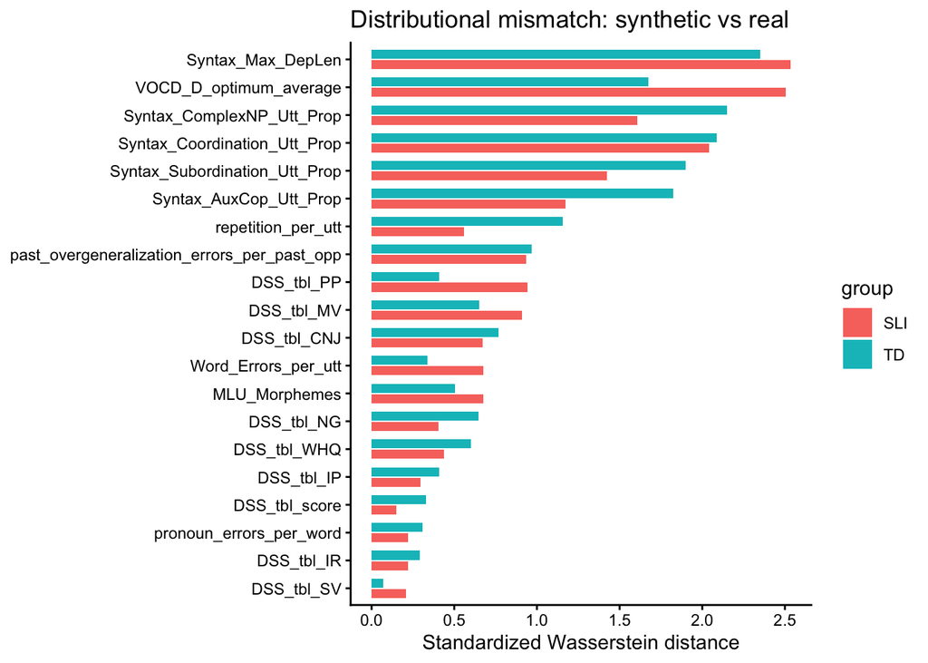

```r
plot_df <- dist_std_results %>%
  group_by(feature) %>%
  mutate(max_w = max(wasserstein_std, na.rm = TRUE)) %>%
  ungroup() %>%
  mutate(
    feature = reorder(feature, max_w)
  )

ggplot(plot_df, aes(x = feature, y = wasserstein_std, fill = group)) +
  geom_col(position = position_dodge(width = 0.75), width = 0.65) +
  coord_flip() +
  labs(
    x = NULL,
    y = "Standardized Wasserstein distance",
    title = "Distributional mismatch: synthetic vs real"
  ) +
  theme_classic()
```

## Covariance/correlation preservation

```r
library(dplyr)
library(tibble)
library(tidyr)
library(ggplot2)

# -----------------------------
# Use the same feature set that entered the PCA
# -----------------------------
broad_features <- colnames(feature_df_pruned)

# If needed, drop known problematic/asymmetric features here too
broad_features <- setdiff(
  broad_features,
  c("retracing_per_utt")
)
# add "repetition_per_utt" too if you decide it should be excluded:
# broad_features <- setdiff(broad_features, c("retracing_per_utt", "repetition_per_utt"))

# -----------------------------
# Use the independent transcript-level 4–7 dataset
# same one used for PCA
# -----------------------------
corr_base <- pca_complete %>%
  select(population, source, clinical_group, all_of(broad_features))

table(corr_base$population)
```

```
##
##       Real TD  Synthetic TD      Real SLI Synthetic SLI
##           189           470            47           470
```

```r
# -----------------------------
# Helper functions
# -----------------------------
upper_tri_vec <- function(mat) {
  mat[upper.tri(mat)]
}

get_corr_mat <- function(df, group_name, feature_names) {
  tmp <- df %>%
    filter(clinical_group == group_name) %>%
    select(source, all_of(feature_names))

  real_df <- tmp %>%
    filter(source == "real") %>%
    select(-source)

  syn_df <- tmp %>%
    filter(source == "synthetic") %>%
    select(-source)

  # keep only features with non-zero variance in BOTH real and synthetic
  keep_vars <- intersect(
    names(real_df)[sapply(real_df, function(x) sd(x, na.rm = TRUE) > 0)],
    names(syn_df)[sapply(syn_df, function(x) sd(x, na.rm = TRUE) > 0)]
  )

  real_df <- real_df %>% select(all_of(keep_vars))
  syn_df  <- syn_df  %>% select(all_of(keep_vars))

  list(
    keep_vars = keep_vars,
    real = cor(real_df, use = "pairwise.complete.obs"),
    synthetic = cor(syn_df, use = "pairwise.complete.obs")
  )
}

corr_similarity <- function(cor_real, cor_syn) {
  v1 <- upper_tri_vec(cor_real)
  v2 <- upper_tri_vec(cor_syn)

  tibble(
    corr_of_correlations = cor(v1, v2, use = "complete.obs"),
    mean_abs_diff = mean(abs(v1 - v2), na.rm = TRUE),
    max_abs_diff = max(abs(v1 - v2), na.rm = TRUE),
    frobenius = sqrt(sum((cor_real - cor_syn)^2, na.rm = TRUE))
  )
}
```

```r
# -----------------------------
# Compute TD and SLI correlation matrices
# -----------------------------
corr_td_broad  <- get_corr_mat(corr_base, "TD", broad_features)
corr_sli_broad <- get_corr_mat(corr_base, "SLI", broad_features)

length(corr_td_broad$keep_vars)
```

```
## [1] 20
```

```r
length(corr_sli_broad$keep_vars)
```

```
## [1] 20
```

```r
setdiff(broad_features, corr_td_broad$keep_vars)
```

```
## character(0)
```

```r
setdiff(broad_features, corr_sli_broad$keep_vars)
```

```
## character(0)
```

```r
td_similarity_broad  <- corr_similarity(corr_td_broad$real,  corr_td_broad$synthetic)
sli_similarity_broad <- corr_similarity(corr_sli_broad$real, corr_sli_broad$synthetic)

td_similarity_broad
```

```
## # A tibble: 1 × 4
##   corr_of_correlations mean_abs_diff max_abs_diff frobenius
##                  <dbl>         <dbl>        <dbl>     <dbl>
## 1                0.270         0.244        0.948      6.36
```

```r
sli_similarity_broad
```

```
## # A tibble: 1 × 4
##   corr_of_correlations mean_abs_diff max_abs_diff frobenius
##                  <dbl>         <dbl>        <dbl>     <dbl>
## 1                0.274         0.258         1.07      6.79
```

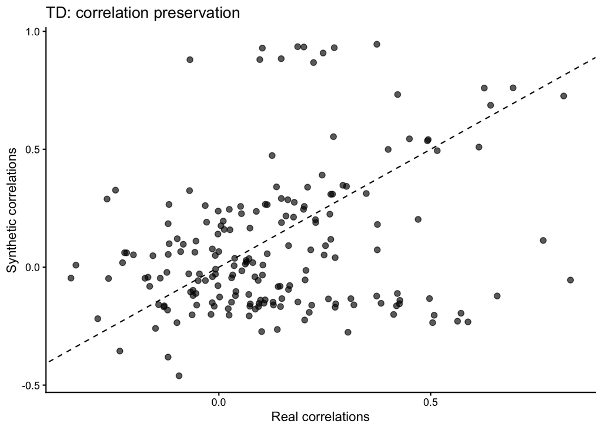

```r
plot_corr_preservation <- function(cor_real, cor_syn, title_text) {
  df_plot <- tibble(
    real = upper_tri_vec(cor_real),
    synthetic = upper_tri_vec(cor_syn)
  )

  ggplot(df_plot, aes(x = real, y = synthetic)) +
    geom_point(alpha = 0.65, size = 2) +
    geom_abline(slope = 1, intercept = 0, linetype = "dashed") +
    labs(
      x = "Real correlations",
      y = "Synthetic correlations",
      title = title_text
    ) +
    theme_classic()
}

plot_corr_preservation(
  corr_td_broad$real,
  corr_td_broad$synthetic,
  "TD: correlation preservation"
)
```

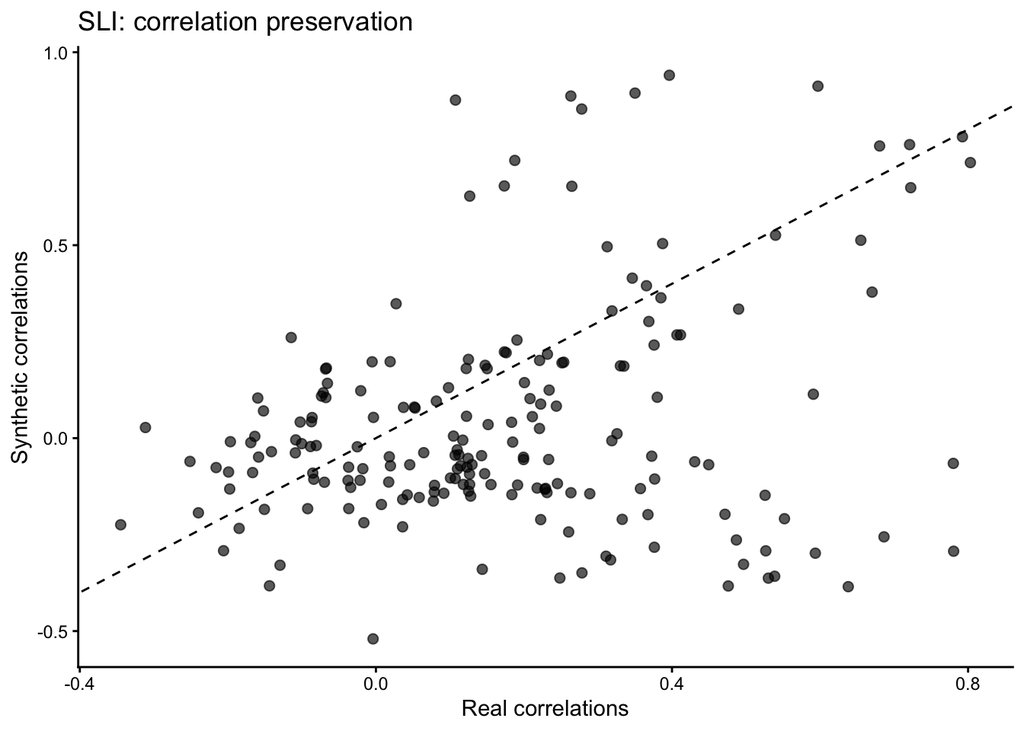

```r
plot_corr_preservation(
  corr_sli_broad$real,
  corr_sli_broad$synthetic,
  "SLI: correlation preservation"
)
```

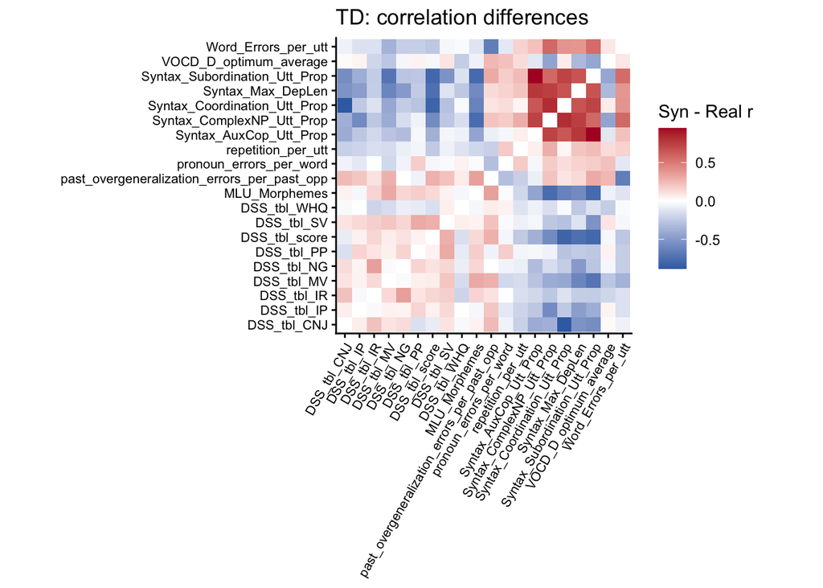

```r
plot_corr_diff <- function(cor_real, cor_syn, title_text) {
  diff_mat <- cor_syn - cor_real

  as.data.frame(diff_mat) %>%
    rownames_to_column("feature1") %>%
    pivot_longer(-feature1, names_to = "feature2", values_to = "diff") %>%
    ggplot(aes(x = feature1, y = feature2, fill = diff)) +
    geom_tile() +
    scale_fill_gradient2(
      low = "#2166ac",
      mid = "white",
      high = "#b2182b",
      midpoint = 0
    ) +
    coord_equal() +
    labs(
      x = NULL,
      y = NULL,
      fill = "Syn - Real r",
      title = title_text
    ) +
    theme_classic() +
    theme(
      axis.text.x = element_text(angle = 60, hjust = 1, size = 8),
      axis.text.y = element_text(size = 8)
    )
}

plot_corr_diff(
  corr_td_broad$real,
  corr_td_broad$synthetic,
  "TD: correlation differences"
)
```

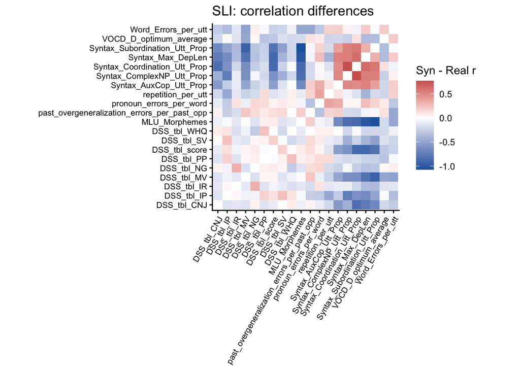

```r
plot_corr_diff(
  corr_sli_broad$real,
  corr_sli_broad$synthetic,
  "SLI: correlation differences"
)
```

RED = synthetic correlation > real BLUE = synthetic correlation < real

The synthetic data do not just shift feature values; they change the architecture of the profile.

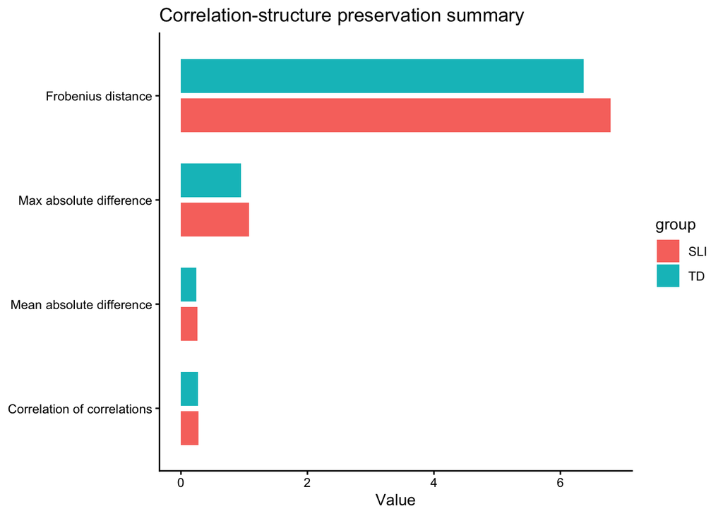

```r
corr_summary_plot <- bind_rows(
  td_similarity_broad  %>% mutate(group = "TD"),
  sli_similarity_broad %>% mutate(group = "SLI")
) %>%
  pivot_longer(
    cols = c(corr_of_correlations, mean_abs_diff, max_abs_diff, frobenius),
    names_to = "metric",
    values_to = "value"
  ) %>%
  mutate(
    metric = factor(
      metric,
      levels = c("corr_of_correlations", "mean_abs_diff", "max_abs_diff", "frobenius"),
      labels = c(
        "Correlation of correlations",
        "Mean absolute difference",
        "Max absolute difference",
        "Frobenius distance"
      )
    )
  )

ggplot(corr_summary_plot, aes(x = metric, y = value, fill = group)) +
  geom_col(position = position_dodge(width = 0.75), width = 0.65) +
  coord_flip() +
  labs(
    x = NULL,
    y = "Value",
    title = "Correlation-structure preservation summary"
  ) +
  theme_classic()
```

```r
top_corr_diffs <- function(cor_real, cor_syn, top_n = 15) {
  diff_mat <- cor_syn - cor_real
  abs_diff_mat <- abs(diff_mat)

  as.data.frame(abs_diff_mat) %>%
    rownames_to_column("feature1") %>%
    pivot_longer(-feature1, names_to = "feature2", values_to = "abs_diff") %>%
    mutate(signed_diff = as.vector(diff_mat)) %>%
    filter(feature1 != feature2) %>%
    rowwise() %>%
    mutate(pair = paste(sort(c(feature1, feature2)), collapse = " -- ")) %>%
    ungroup() %>%
    distinct(pair, .keep_all = TRUE) %>%
    arrange(desc(abs_diff)) %>%
    slice_head(n = top_n) %>%
    select(pair, abs_diff, signed_diff)
}

top_td_broad  <- top_corr_diffs(corr_td_broad$real,  corr_td_broad$synthetic, top_n = 15)
top_sli_broad <- top_corr_diffs(corr_sli_broad$real, corr_sli_broad$synthetic, top_n = 15)

top_td_broad
```

```
## # A tibble: 15 × 3
##    pair                                                     abs_diff signed_diff
##    <chr>                                                       <dbl>       <dbl>
##  1 Syntax_AuxCop_Utt_Prop -- Syntax_Subordination_Utt_Prop     0.948       0.948
##  2 DSS_tbl_CNJ -- Syntax_Coordination_Utt_Prop                 0.885      -0.885
##  3 Syntax_ComplexNP_Utt_Prop -- Syntax_Coordination_Utt_Pr…    0.826       0.826
##  4 DSS_tbl_score -- Syntax_Coordination_Utt_Prop               0.820      -0.820
##  5 DSS_tbl_score -- Syntax_Subordination_Utt_Prop              0.793      -0.793
##  6 Syntax_AuxCop_Utt_Prop -- Syntax_Max_DepLen                 0.784       0.784
##  7 MLU_Morphemes -- Syntax_Subordination_Utt_Prop              0.779      -0.779
##  8 MLU_Morphemes -- Syntax_ComplexNP_Utt_Prop                  0.767      -0.767
##  9 Syntax_ComplexNP_Utt_Prop -- Syntax_Max_DepLen              0.749       0.749
## 10 DSS_tbl_score -- Syntax_Max_DepLen                          0.740      -0.740
## 11 Syntax_AuxCop_Utt_Prop -- Syntax_ComplexNP_Utt_Prop         0.737       0.737
## 12 Syntax_Coordination_Utt_Prop -- Syntax_Subordination_Ut…    0.733       0.733
## 13 DSS_tbl_MV -- Syntax_Subordination_Utt_Prop                 0.712      -0.712
## 14 Syntax_Coordination_Utt_Prop -- Syntax_Max_DepLen           0.662       0.662
## 15 Syntax_Max_DepLen -- Syntax_Subordination_Utt_Prop          0.658       0.658
```

```r
top_sli_broad
```

```
## # A tibble: 15 × 3
##    pair                                                     abs_diff signed_diff
##    <chr>                                                       <dbl>       <dbl>
##  1 MLU_Morphemes -- Syntax_Subordination_Utt_Prop              1.07       -1.07
##  2 MLU_Morphemes -- Syntax_Max_DepLen                          1.02       -1.02
##  3 DSS_tbl_MV -- Syntax_Subordination_Utt_Prop                 0.942      -0.942
##  4 DSS_tbl_score -- Syntax_Max_DepLen                          0.897      -0.897
##  5 MLU_Morphemes -- Syntax_Coordination_Utt_Prop               0.893      -0.893
##  6 DSS_tbl_score -- Syntax_Coordination_Utt_Prop               0.892      -0.892
##  7 MLU_Morphemes -- Syntax_ComplexNP_Utt_Prop                  0.859      -0.859
##  8 DSS_tbl_CNJ -- Syntax_Coordination_Utt_Prop                 0.845      -0.845
##  9 DSS_tbl_MV -- Syntax_Max_DepLen                             0.824      -0.824
## 10 DSS_tbl_score -- Syntax_Subordination_Utt_Prop              0.819      -0.819
## 11 Syntax_ComplexNP_Utt_Prop -- Syntax_Coordination_Utt_Pr…    0.769       0.769
## 12 DSS_tbl_CNJ -- Syntax_Max_DepLen                            0.761      -0.761
## 13 DSS_tbl_IP -- Syntax_ComplexNP_Utt_Prop                     0.751      -0.751
## 14 DSS_tbl_CNJ -- Syntax_Subordination_Utt_Prop                0.674      -0.674
## 15 MLU_Morphemes -- Syntax_AuxCop_Utt_Prop                     0.669      -0.669
```

## Linear Mixed-Effects Models

round_batch as fixed or random effect?

```r
m_fixed <- lmer(
  MLU_Morphemes ~ source_is_synthetic * clinical_group +
    Age_c + factor(round_batch) + (1 | cluster_id),
  data = df_all, REML = FALSE
)

m_random <- lmer(
  MLU_Morphemes ~ source_is_synthetic * clinical_group +
    Age_c + (1 | round_batch) + (1 | cluster_id),
  data = df_all, REML = FALSE
)
```

```
## boundary (singular) fit: see help('isSingular')
```

```r
AIC(m_fixed, m_random)
```

```
##          df      AIC
## m_fixed  23 3881.264
## m_random  8 3856.773
```

```r
BIC(m_fixed, m_random)
```

```
##          df      BIC
## m_fixed  23 4008.304
## m_random  8 3900.961
```

```r
summary(m_fixed)
```

```
## Linear mixed model fit by maximum likelihood . t-tests use Satterthwaite's
##   method [lmerModLmerTest]
## Formula: MLU_Morphemes ~ source_is_synthetic * clinical_group + Age_c +
##     factor(round_batch) + (1 | cluster_id)
##    Data: df_all
##
##       AIC       BIC    logLik -2*log(L)  df.resid
##    3881.3    4008.3   -1917.6    3835.3      1828
##
## Scaled residuals:
##     Min      1Q  Median      3Q     Max
## -4.0171 -0.2761  0.0030  0.1995  6.2445
##
## Random effects:
##  Groups     Name        Variance Std.Dev.
##  cluster_id (Intercept) 0.8722   0.9339
##  Residual               0.3059   0.5531
## Number of obs: 1851, groups:  cluster_id, 283
##
## Fixed effects:
##                                          Estimate Std. Error         df t value
## (Intercept)                             7.160e+00  3.708e-01  3.187e+02  19.309
## source_is_synthetic                     5.514e-01  1.559e-01  2.624e+02   3.538
## clinical_groupSLI                      -1.385e+00  1.602e-01  2.926e+02  -8.646
## Age_c                                   5.012e-02  1.843e-02  2.973e+02   2.719
## factor(round_batch)5_year_old.round_01  2.111e-01  2.674e-01  3.771e+02   0.790
## factor(round_batch)6_year_old.round_01 -2.241e-01  4.719e-01  3.196e+02  -0.475
## factor(round_batch)7_year_old.round_01 -7.343e-02  6.744e-01  3.080e+02  -0.109
## factor(round_batch)4_year_old.round_02  3.685e-03  1.138e-01  1.648e+03   0.032
## factor(round_batch)5_year_old.round_02  2.149e-01  2.677e-01  3.790e+02   0.803
## factor(round_batch)6_year_old.round_02 -2.314e-01  4.724e-01  3.213e+02  -0.490
## factor(round_batch)7_year_old.round_02 -7.287e-02  6.748e-01  3.087e+02  -0.108
## factor(round_batch)4_year_old.round_03  1.296e-03  1.138e-01  1.648e+03   0.011
## factor(round_batch)5_year_old.round_03  1.992e-01  2.679e-01  3.805e+02   0.744
## factor(round_batch)6_year_old.round_03 -2.259e-01  4.726e-01  3.220e+02  -0.478
## factor(round_batch)7_year_old.round_03 -6.745e-02  6.752e-01  3.095e+02  -0.100
## factor(round_batch)4_year_old.round_04  8.167e-03  1.125e-01  1.633e+03   0.073
## factor(round_batch)5_year_old.round_04  1.931e-01  2.682e-01  3.828e+02   0.720
## factor(round_batch)6_year_old.round_04 -2.265e-01  4.726e-01  3.221e+02  -0.479
## factor(round_batch)7_year_old.round_04 -7.950e-02  6.754e-01  3.100e+02  -0.118
```

[output cut: 11 more lines]

```
## factor(round_batch)5_year_old.round_02 0.422488
## factor(round_batch)6_year_old.round_02 0.624613
## factor(round_batch)7_year_old.round_02 0.914072
## factor(round_batch)4_year_old.round_03 0.990916
## factor(round_batch)5_year_old.round_03 0.457519
## factor(round_batch)6_year_old.round_03 0.632962
## factor(round_batch)7_year_old.round_03 0.920493
## factor(round_batch)4_year_old.round_04 0.942133
## factor(round_batch)5_year_old.round_04 0.472036
## factor(round_batch)6_year_old.round_04 0.632141
## factor(round_batch)7_year_old.round_04 0.906382
## factor(round_batch)7_year_old.round_05 0.917479
## source_is_synthetic:clinical_groupSLI  0.020380 *
## ---
## Signif. codes:  0 '***' 0.001 '**' 0.01 '*' 0.05 '.' 0.1 ' ' 1
```

```
##
## Correlation matrix not shown by default, as p = 21 > 12.
## Use print(x, correlation=TRUE)  or
##     vcov(x)        if you need it
```

```r
summary(m_random)
```

```
## Linear mixed model fit by maximum likelihood . t-tests use Satterthwaite's
##   method [lmerModLmerTest]
## Formula: MLU_Morphemes ~ source_is_synthetic * clinical_group + Age_c +
##     (1 | round_batch) + (1 | cluster_id)
##    Data: df_all
##
##       AIC       BIC    logLik -2*log(L)  df.resid
##    3856.8    3901.0   -1920.4    3840.8      1843
##
## Scaled residuals:
##     Min      1Q  Median      3Q     Max
## -4.0156 -0.2686  0.0016  0.2003  6.2482
##
## Random effects:
##  Groups      Name        Variance Std.Dev.
##  cluster_id  (Intercept) 0.8896   0.9432
##  round_batch (Intercept) 0.0000   0.0000
##  Residual                0.3060   0.5532
## Number of obs: 1851, groups:  cluster_id, 283; round_batch, 17
##
## Fixed effects:
##                                         Estimate Std. Error         df t value
## (Intercept)                             7.128326   0.071609 285.710990  99.545
## source_is_synthetic                     0.560473   0.157157 263.894296   3.566
## clinical_groupSLI                      -1.375071   0.161452 293.921736  -8.517
## Age_c                                   0.044349   0.004285 279.787091  10.349
## source_is_synthetic:clinical_groupSLI   0.372780   0.165435 323.774431   2.253
##                                       Pr(>|t|)
## (Intercept)                            < 2e-16 ***
## source_is_synthetic                    0.00043 ***
## clinical_groupSLI                     8.62e-16 ***
## Age_c                                  < 2e-16 ***
## source_is_synthetic:clinical_groupSLI  0.02491 *
## ---
## Signif. codes:  0 '***' 0.001 '**' 0.01 '*' 0.05 '.' 0.1 ' ' 1
##
## Correlation of Fixed Effects:
##             (Intr) src_s_ cl_SLI Age_c
## src_s_synth -0.455
## clncl_grSLI -0.443  0.202
## Age_c        0.040 -0.005 -0.010
## src_s_:_SLI  0.433 -0.222 -0.976  0.009
## optimizer (nloptwrap) convergence code: 0 (OK)
## boundary (singular) fit: see help('isSingular')
```

```r
VarCorr(m_random)
```

```
##  Groups      Name        Std.Dev.
##  cluster_id  (Intercept) 0.94316
##  round_batch (Intercept) 0.00000
##  Residual                0.55318
```

keep round_batch as fixed-effect sensitivity check.